# Lab 3

Sarah Roffo

10/4/2017

## Question 1

### Question 1a: Randomly select 40 cars as the training dataset and the remaining 53 cars as the test dataset

```r
set.seed(1234)
training_dataset <- sample(1:nrow(df), 40, replace = FALSE)
index <- as.numeric(row.names(df))
test_dataset <- index[- training_dataset]
training_df <- df[training_dataset,]
training_df ## Training Dataset
```

```
##     Manufacturer        Model    Type Min.Price Price Max.Price MPG.city
## 11      Cadillac      Seville Midsize      37.5  40.1      42.7       16
## 58 Mercedes-Benz         190E Compact      29.0  31.9      34.9       20
## 56         Mazda          MPV     Van      16.6  19.1      21.7       18
## 57         Mazda         RX-7  Sporty      32.5  32.5      32.5       17
## 77       Pontiac   Bonneville   Large      19.4  24.4      29.4       19
## 90    Volkswagen       Passat Compact      17.6  20.0      22.4       21
## 1          Acura      Integra   Small      12.9  15.9      18.8       25
## 20      Chrylser     Concorde   Large      18.4  18.4      18.4       20
## 88    Volkswagen          Fox   Small       8.7   9.1       9.5       25
## 44       Hyundai        Excel   Small       6.8   8.0       9.2       29
## 92         Volvo          240 Compact      21.8  22.7      23.5       21
## 45       Hyundai      Elantra   Small       9.0  10.0      11.0       22
## 23         Dodge         Colt   Small       7.9   9.2      10.6       29
## 74       Pontiac      Sunbird Compact       9.4  11.1      12.8       23
```

[output cut: 190 more lines]

```r
test_df <- df[test_dataset,]
test_df ## Test Dataset
```

```
##     Manufacturer          Model    Type Min.Price Price Max.Price MPG.city
## 2          Acura         Legend Midsize      29.2  33.9      38.7       18
## 4           Audi            100 Midsize      30.8  37.7      44.6       19
## 5            BMW           535i Midsize      23.7  30.0      36.2       22
## 6          Buick        Century Midsize      14.2  15.7      17.3       22
## 7          Buick        LeSabre   Large      19.9  20.8      21.7       19
## 8          Buick     Roadmaster   Large      22.6  23.7      24.9       16
## 9          Buick        Riviera Midsize      26.3  26.3      26.3       19
## 10      Cadillac        DeVille   Large      33.0  34.7      36.3       16
## 13     Chevrolet        Corsica Compact      11.4  11.4      11.4       25
## 14     Chevrolet         Camaro  Sporty      13.4  15.1      16.8       19
## 25         Dodge         Spirit Compact      11.9  13.3      14.7       22
## 26         Dodge        Caravan     Van      13.6  19.0      24.4       17
## 27         Dodge        Dynasty Midsize      14.8  15.6      16.4       21
## 28         Dodge        Stealth  Sporty      18.5  25.8      33.1       18
```

[output cut: 255 more lines]

### Question 1b: Save both datasets as csv files

```r
write.csv(training_df, file = "training_df.csv")
write.csv(test_df, file = "test_df.csv")
```

### Question 1c: Find out the number of USA and non-USA cars in the training dataset

```r
USA_training_df <- training_df[training_df$Origin == "USA",]
nrow(USA_training_df) ##number of USA cars in the training dataset
```

```
## [1] 22
```

```r
non_USA_training_df <- training_df[training_df$Origin == "non-USA",]
nrow(non_USA_training_df) ##number of non-USA cars in the training dataset
```

```
## [1] 18
```

## Question 2

### Question 2a: Assume that the probability of boy and girl births are 0.515 and 0.485, respectively. Use the sample() function to simulate 10 births and print out the result. How many boys and girls do you get out of 10 births?

```r
births <- sample(c("boy", "girl"), size = 10, replace = TRUE, prob = c(0.515, 0.485))
table(births)
```

```
## births
##  boy girl
##    5    5
```

### Question 2b: Simulate 10,000 births. How many boys and girls do you get out of 10,000 births?

```r
many_births <- sample(c("boy", "girl"), size = 10000, replace = TRUE, prob = c(0.515, 0.485))
table(many_births)
```

```
## many_births
##  boy girl
## 5140 4860
```

## Question 3

### Question 3a: Assume that the probabilities of boy and girl births are 0.515 and 0.485, respectively. What is the probability of having exactly 3 boys out of 10 births?

```r
prob_3_boys <- dbinom(3, size = 10, prob = 0.515)
prob_3_boys ##probability of exactly 3 boys out of 10 births
```

```
## [1] 0.1034654
```

### Question 3b: What is the probability of having 8 or more boys out of 10 births?

```r
prob_8_or_more <- pbinom(7, size = 10, prob = 0.515, lower.tail = FALSE)
prob_8_or_more ##probability of 8 or more boys out of 10 births
```

```
## [1] 0.06605068
```

### Question 3c: Plot both the density function and cumulative probability function of the number of boy births out of 10.

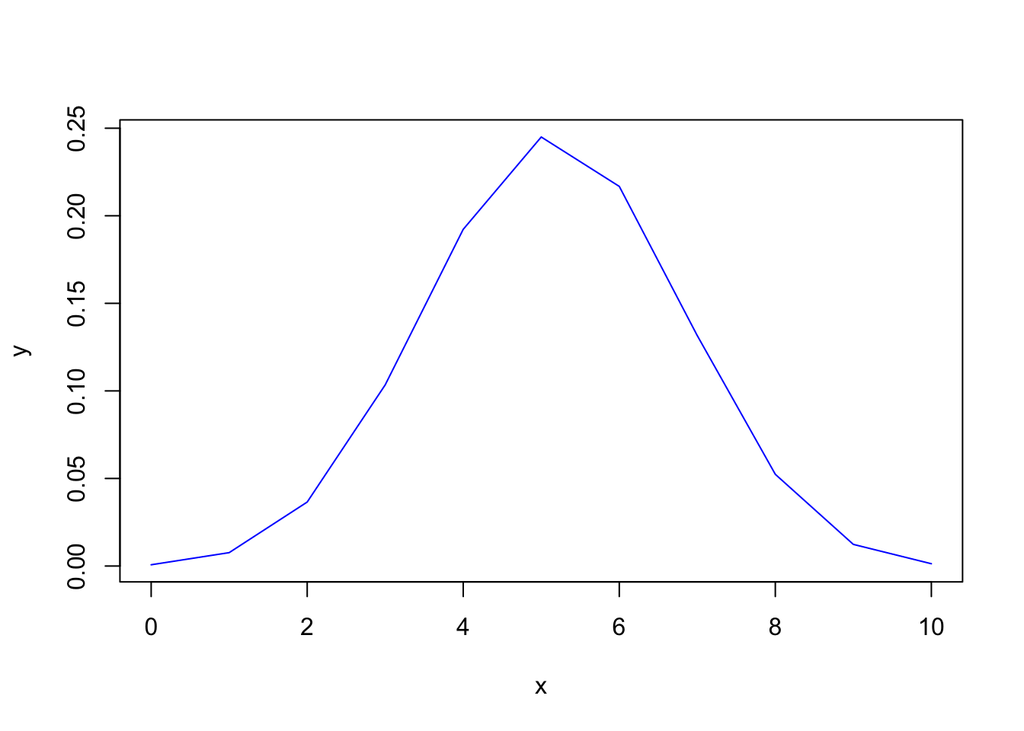

```r
n <- 10
x <- 0:n
y <- dbinom(x, size = 10, prob = 0.515)
plot(x,y, type = "l", pch = 16, col = "blue") ## Density Function
```

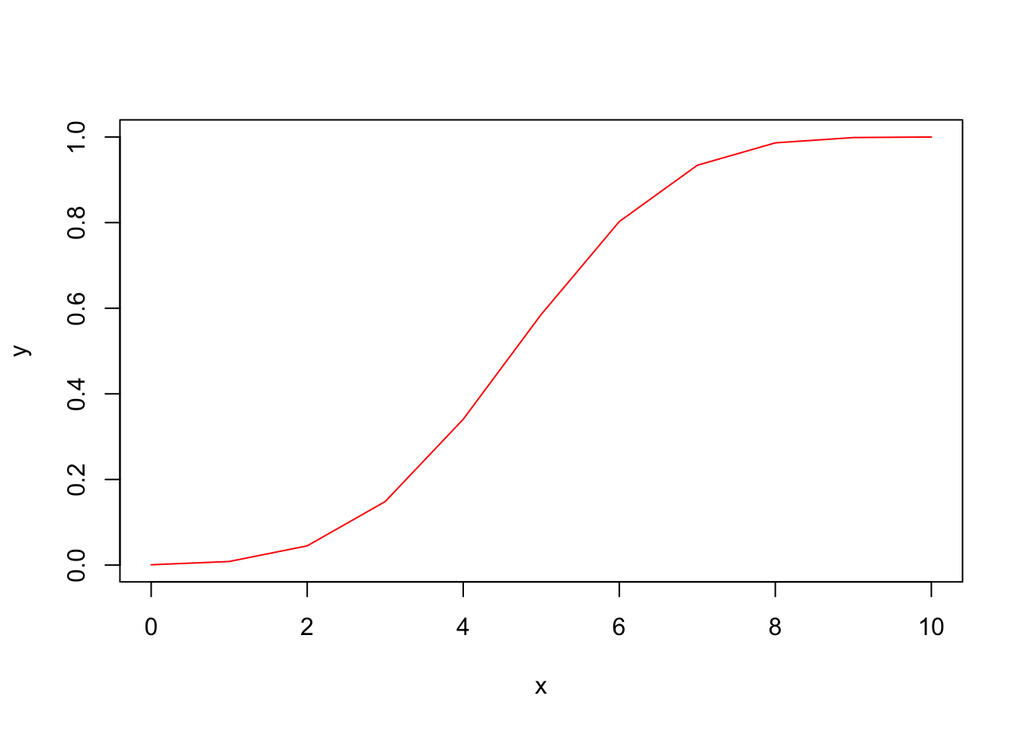

```r
n <- 10
x <- 0:n
y <- pbinom(x, size = 10, prob = 0.515)
plot(x,y, type = "l", pch = 16, col = "red") ## Cumulative Probability Function
```

## Question 4

### Question 4a: Cars randomly arrive at a traffic light at the rate of five every ten seconds. What is the probability that exactly 4 cars arrive in the next ten seconds?

```r
prob_exactly_4 <- dpois(4, lambda = 5)
prob_exactly_4 ## Probability that exactly 4 cars arrive in next ten seconds
```

```
## [1] 0.1754674
```

### Question 4b: What is the probability that more than 5 cars arrive in the next ten seconds?

```r
prob_more_than_5 <- ppois(5, lambda = 5, lower.tail = FALSE)
prob_more_than_5 ## Probability that more than 5 cars arrive in next ten seconds
```

```
## [1] 0.3840393
```

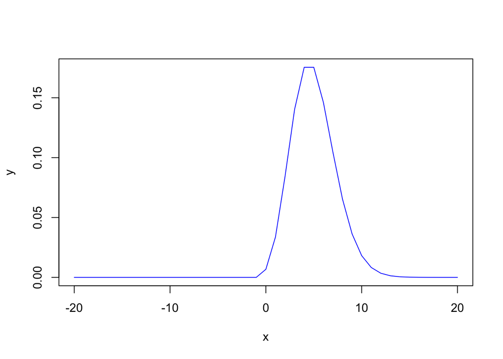

```r
n <- 20
x <- seq(from = -20, to = 20)
y <- dpois(x, lambda = 5)
plot(x, y, type = "l", pch = 16, col = "blue") ## Density Function
```